# Analyses speech patterns in daylong recordings across multiple sites

# Instructions for use

If this is first time that you are running this script, change the redoALL parameter to TRUE so that the first set of chunks, under generate main databases, is recalculated. Make sure you’ve created a folder called “derivedFiles” inside dalohumacosp, since the databases will be stored in that folder. (The folder is not pushed to github.)

# Generate main databases

## Prep

Convert textgrids into csv’s.

## Reading in current coding

Read in all csv’s and clean up.

## Draw summaries per child & file

The goal is to find out how much clean and overlapping speech there is by all of the speakers, summing within each file. This chunk uses code from https://stackoverflow.com/questions/41839268/sum-overlapping-non-overlapping-time-intervals-in-r by Jonathan von Schroeder.

## Generating Proportions & quantities of CHI vocalizations of different types

## Generating Proportion & quantities of FA1 linguistic vocalizations

# Methodological analyses

## How much data are there?

We read in the version of the file that has one line per coded segment. That is, if the child vocalized 3 times in a given minute, an adult 2 times, and another child once, then there will be 6 segments for that *minute*. This is the most fine-grained format of representation, and thus too fine-grained for some of the quantification questions we have. So we will derive tables as needed.

First, we look at how many coded minutes there are for each child and date.

```r
read.table("../derivedFiles/line_per_segment_age.txt",header=T)->all
levels(all$child)-> kids
levels(all$chidate)-> days

#number of coded minutes per child
data.frame(table(all$chidate,all$File))->x
x[x$Freq!=0,]->x

#number of coded days per child
data.frame(table(all$child,all$chidate))->y
y[y$Freq!=0,]->y
```

There are 21 in all, including 9 from Vanuatu and the remaining from Namibia. There are a total of 102 coded, of which 13 from Vanuatu. Although the two sites have roughly the same number of children (coded – there are more uncoded children in Vanuatu), more days have been recorded in Namibia:

```r
table(y$Var1)
```

```
##
## aiku aoaa eiun eoak eoxk noxk noxt oegd oekd outg uebn uoga va10 va12 va14
##    9   10    8   10    2   10    5   10   10    2   10    3    2    2    1
## va18 van4 van5 van6 van7 van8
##    1    3    1    1    1    1
```

The two sites and groups of kids vary in recording length, which is equivalent to number of minutes coded since there is 1 minute per hour that has been coded. This is clear in the following histograms of number of minutes coded separated by site.

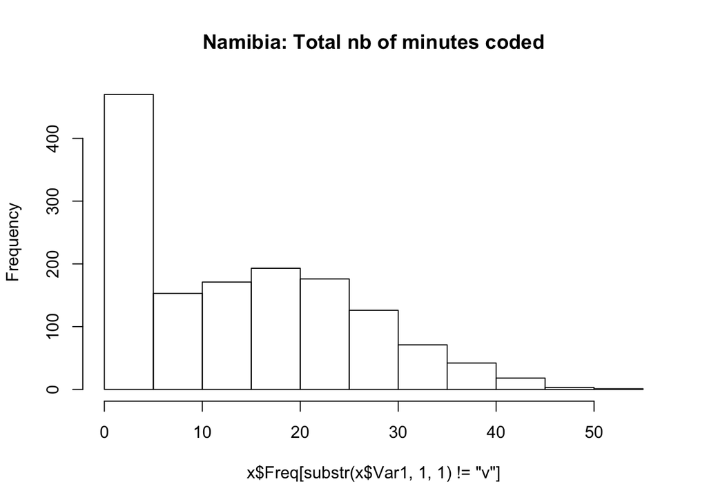

```r
hist(x$Freq[substr(x$Var1,1,1)!="v"],main="Namibia: Total nb of minutes coded")
```

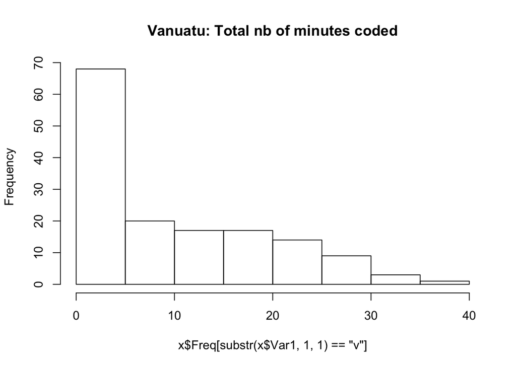

```r
hist(x$Freq[substr(x$Var1,1,1)=="v"],main="Vanuatu: Total nb of minutes coded")
```

The following table shows the number of minutes coded by recording day.

22, 22, 22, 22, 22, 22, 22, 23, 23, 14, 15, 13, 16, 15, 16, 15, 16, 12, 14, 5, 22, 22, 21, 22, 22, 10, 18, 14, 16, 11, 14, 14, 14, 15, 23, 23, 22, 15, 16, 12, 12, 16, 10, 16, 16, 16, 14, 11, 11, 12, 12, 12, 13, 13, 15, 15, 14, 13, 17, 15, 15, 14, 28, 14, 14, 15, 14, 14, 14, 16, 15, 16, 31, 13, 15, 15, 15, 13, 4, 12, 16, 16, 16, 15, 30, 13, 15, 12, 14, 8, 7, 15, 10, 14, 14, 4, 6, 3, 13, 11, 22, 22

I am suspicious of the low number of coded minutes for van4 and va10. It is also surprising to see some very high numbers, like that of uebn2017-03-09… We should check those recordings to see whether something went wrong in the concatenation.

# Theory-relevant analyses

```r
dokidageplot<-function(sumchi,dvname,fancydvname,do_min){
  #dvname="prop";fancydvname="prop"
  #dvname="ling.CFRL";fancydvname=""

  plot(sumchi[,dvname] ~sumchi$age,type="n",main="",yaxt="n",ylab="",xaxt="n",xlab="")
  mtext(fancydvname,2,line=1)
  axis(2,line=-1,tick=F)
  mtext("Age (months)",1,line=1)
  axis(1,line=-1,tick=F)

  mycols=rainbow(length(levels(factor(sumchi$chag))))
names(mycols)<-levels(factor(sumchi$chag))

for(kidag in levels(factor(sumchi$chag))){
  age=mean(sumchi$age[sumchi$chag==kidag],na.rm=T)
  prop=mean(sumchi[sumchi$chag==kidag,dvname],na.rm=T)
  err=sd(sumchi[sumchi$chag==kidag,dvname],na.rm=T)
  text(age,prop,substr(kidag,1,3),col=mycols[kidag])
  lines(c(age,age),c(prop-err,prop+err),col="gray")
}

  for(kid in levels(factor(sumchi$child))){
  props = aggregate(sumchi[sumchi$child==kid,dvname],by=list(sumchi$age[sumchi$child==kid]),mean,na.rm=T)
  for(thisline in 1:(dim(props)[1]-1)) lines(c(props$Group.1[thisline],props$Group.1[thisline+1]),c(props$x[thisline],props$x[thisline+1]),lty=2,col="gray")
}
}

dokidageplot_points<-function(sumchi,dvname,fancydvname){
    #dvname="prop";fancydvname="prop"
mycols=rainbow(length(levels(factor(sumchi$child))))
names(mycols)<-levels(factor(sumchi$child))



    plot(sumchi[,dvname]~sumchi$age,cex=(sumchi[,dvname]/max(sumchi[,dvname],na.rm=T)),main="Data per recording day",xlab="Age (months)",ylab=dvname)
text(sumchi$age,sumchi[,dvname],as.character(sumchi$child),cex=.5,pos=4,col=ifelse(substr(kid,1,1)=="v","black",mycols))

}
```

In all of the following analyses, we will consider four possible dependent measures, all of which control for the fact that we have a lot more coded data for some kids than others:

```
- The quantity of linguistic vocalizations (controlling for recording length)
- The quantity of non-linguistic vocalizations (controlling for recording length)
- The quantity of vocalizations (summing linguistic and non-linguistic) (controlling for recording length)
- The proportion of vocalizations that are linguistic, out of all vocalizations
```

When we say controlling for recording length we mean that these are proportions of the time that has been coded where CHI produces ling vocs. For instance, if kid produced 200 secs of ling vocalizations in a given day, of which 1000 secs have been coded, then they will show up below as .2. We don’t need to do that for the last DV, since the length of vocalizations is already in the denominator.

## How much does CHI vocalize as a function of age?

Focus on linguistic vocalizations:

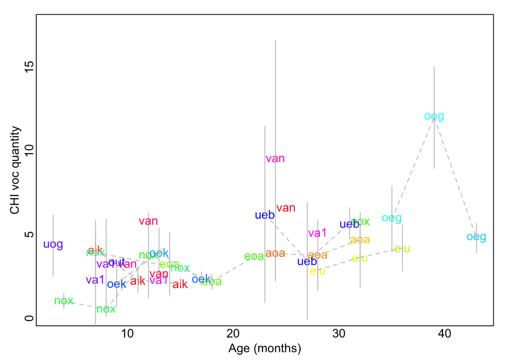

```r
read.table("../derivedFiles/propling_age.txt",header=T)->sumchi

#pdf("ling_age.pdf", height=10, width=15,pointsize = 36)
  par(mar=c(2.5, 2.5, 1, 1))
dokidageplot(sumchi,"ling.CFRL.ph","CHI voc quantity")
```

```r
#dev.off()
```

Now non-linguistic vocalizations:

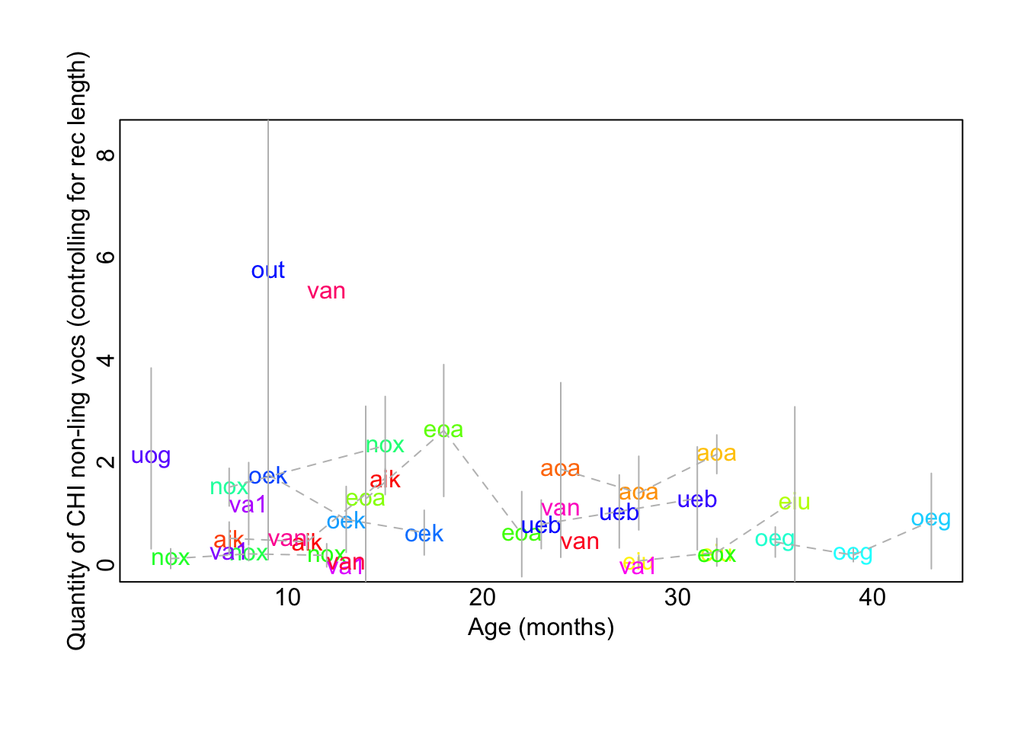

```r
dokidageplot(sumchi,"nonling.CFRL.ph","Quantity of CHI non-ling vocs (controlling for rec length)")
```

Now total vocalizations:

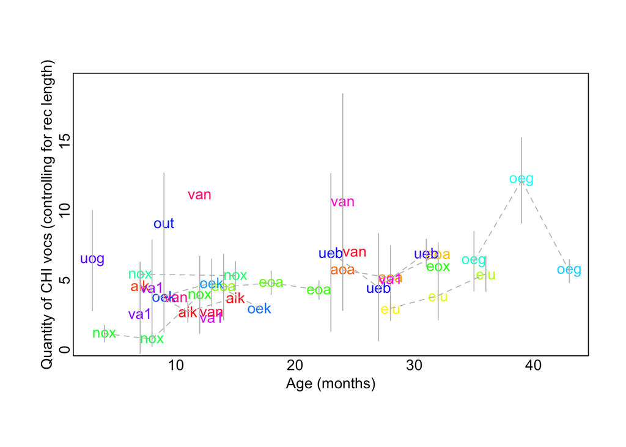

```r
dokidageplot(sumchi,"all.CFRL.ph","Quantity of CHI vocs (controlling for rec length)")
```

And finally, the ratio of ling to all vocs:

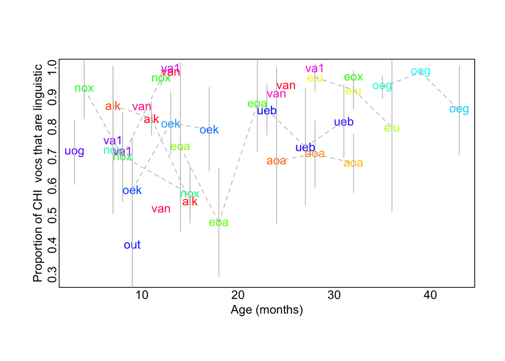

```r
dokidageplot(sumchi,"prop","Proportion of CHI  vocs that are linguistic")
```

## How much does MOTHER vocalize as a function of age?

Please note that we believe our “mother” coding to be a lot less reliable in Vanuatu than Namibia. For adults, it doesn’t make a lot of sense to look at proportion of vocs that are linguistic, so we just plot quantity of linguistic and quantity total (ling + nonling).

Focus on linguistic vocalizations:

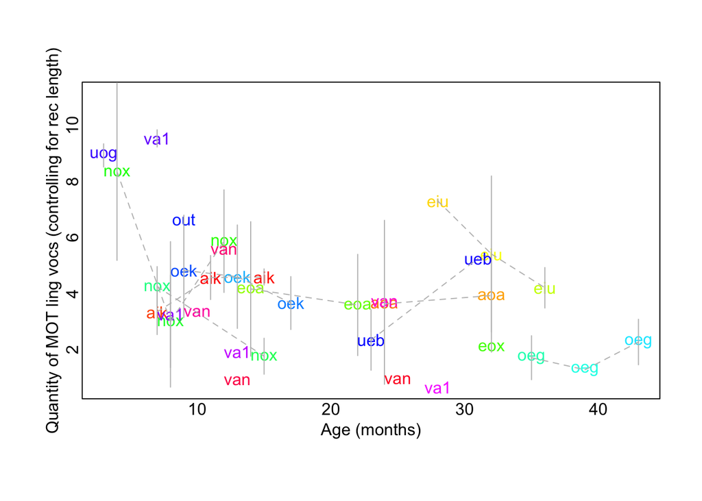

```r
read.table("../derivedFiles/propling_age_MOT.txt",header=T)->summot


dokidageplot(summot,"ling.CFRL.ph","Quantity of MOT ling vocs (controlling for rec length)")
```

Now total vocalizations:

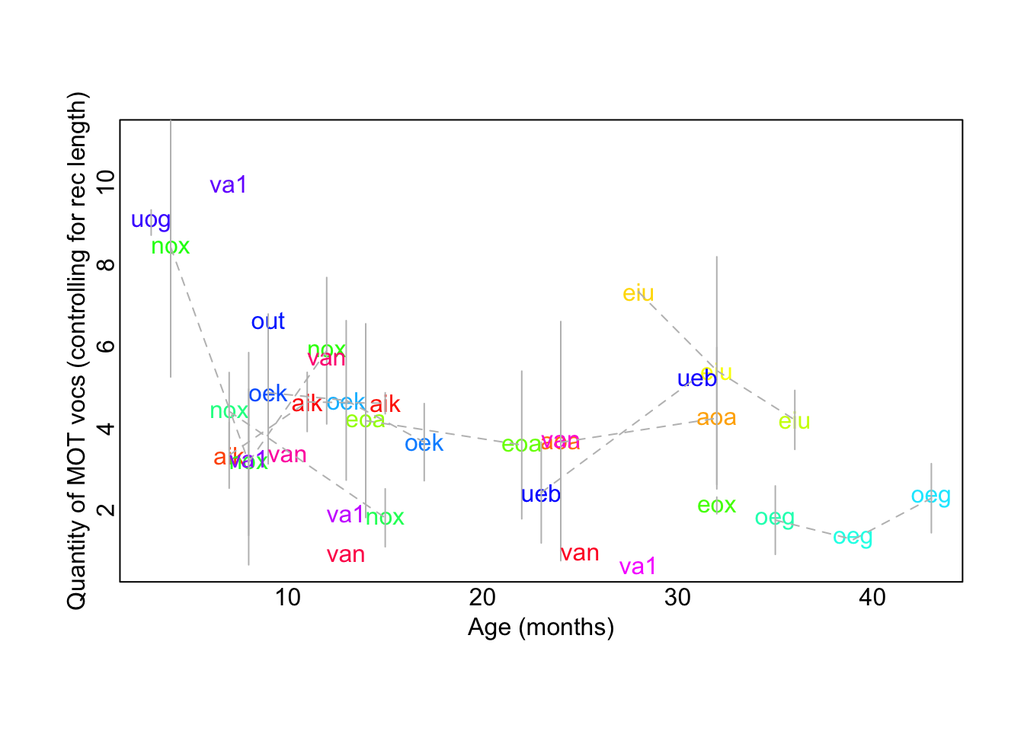

```r
dokidageplot(summot,"all.CFRL.ph","Quantity of MOT vocs (controlling for rec length)")
```

## How much input is there, as a function of age?

Since overheard versus child-directed has not yet been coded, this is total input

ATTENTION, CONVERTING INTO MINUTES BELOW

```r
read.table("../derivedFiles/sum_per_visit_per_type.txt",header=T)-> sums_visit

sums_visit[grep("CHI",sums_visit$source,invert=T),]->sums_visit

sums_visit$speakerID_broad=substr(sums_visit$source,1,1)
sums_visit$speakerID_broad[grep(" ",sums_visit$source)]  <-"overlap"
sums_visit$speakerID_broad[sums_visit$source=="XOL"]  <-"overlap"
sums_visit$speakerID_broad[sums_visit$source=="FA1"]  <-"MOT"
table(sums_visit$speakerID_broad)
```

```
##
##       F       M     MOT       U overlap
##      63      67      35      71    1346
```

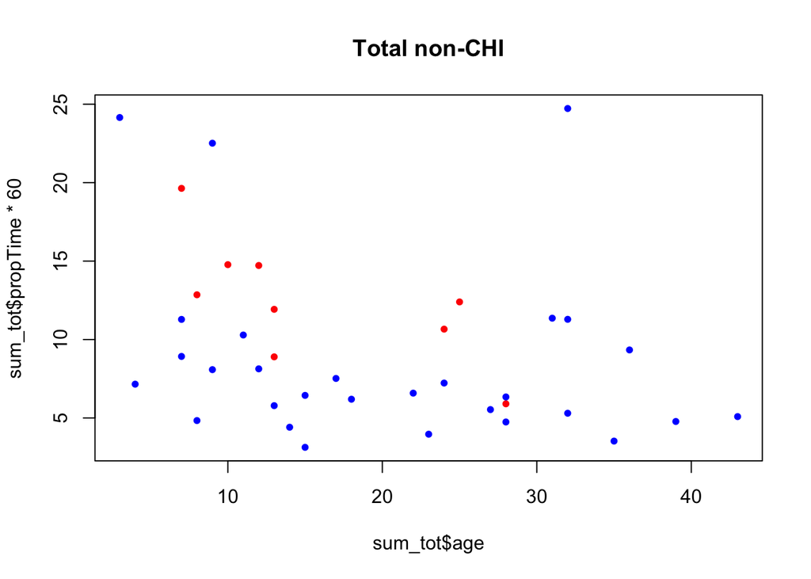

```r
#SPLIT BY BROAD TYPES
aggregate(sums_visit$prop,by=list(sums_visit$key,sums_visit$speakerID_broad,sums_visit$age),sum,na.rm=T)->sum_tot_broad_type #since here we are collapsing across subtypes, we should do SUM, not MEAN
colnames(sum_tot_broad_type)<-c("key","speakerID_broad","age","propTime")

#NO SPLITS
aggregate(sums_visit$prop,by=list(sums_visit$key,sums_visit$age),sum,na.rm=T)->sum_tot #since here we are collapsing across subtypes, we should do SUM, not MEAN
colnames(sum_tot)<-c("key","age","propTime")


plot(sum_tot$propTime*60 ~ sum_tot$age,col=ifelse(substr(as.character(sum_tot$key),7,7)=="v","red","blue"),pch=20,main="Total non-CHI")
```

## How much of the input comes from mother versus other adults versus other kids?

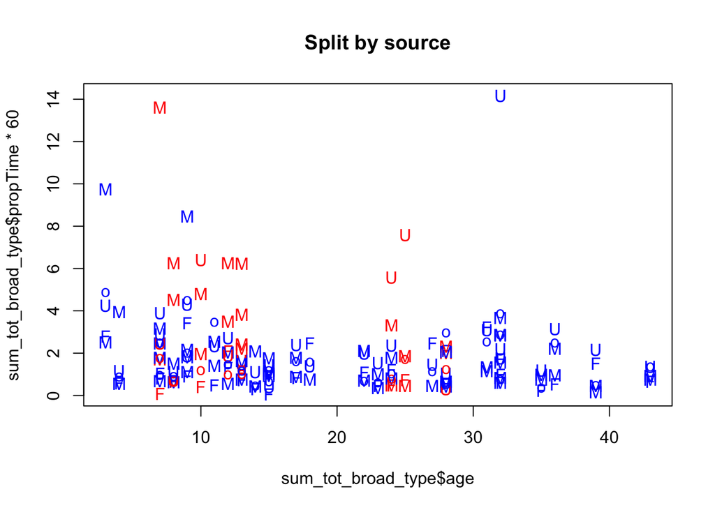

```r
plot(sum_tot_broad_type$propTime*60 ~ sum_tot_broad_type$age,col=ifelse(substr(as.character(sum_tot_broad_type$key),7,7)=="v","red","blue"),pch=substr(sum_tot_broad_type$speakerID_broad,1,1),main="Split by source")
```

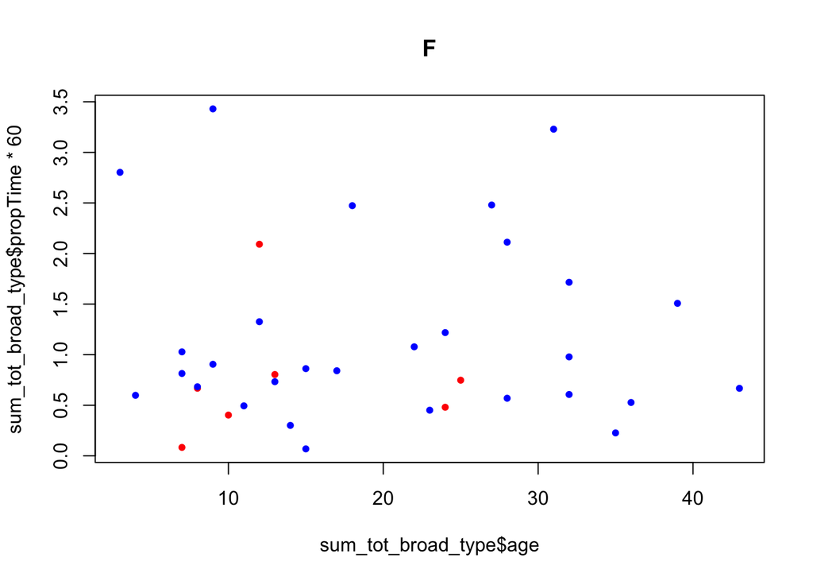

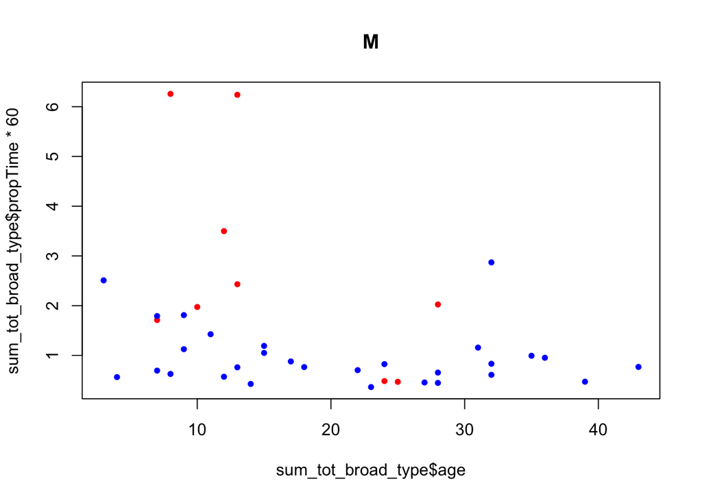

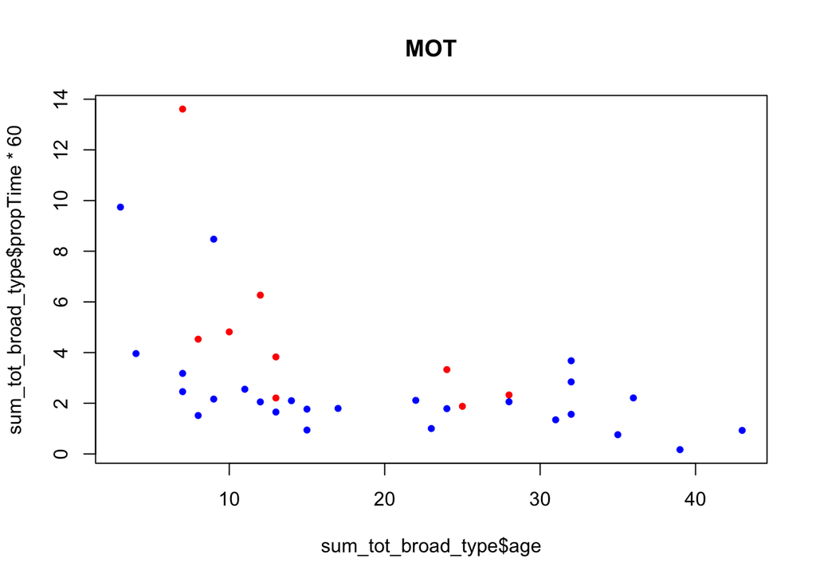

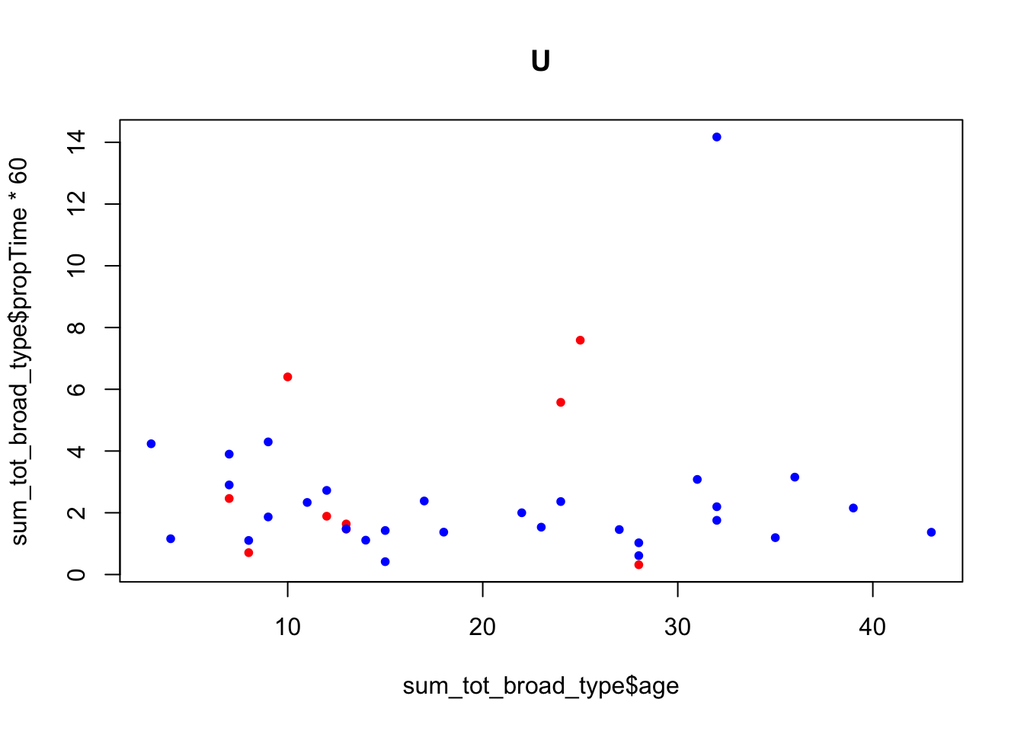

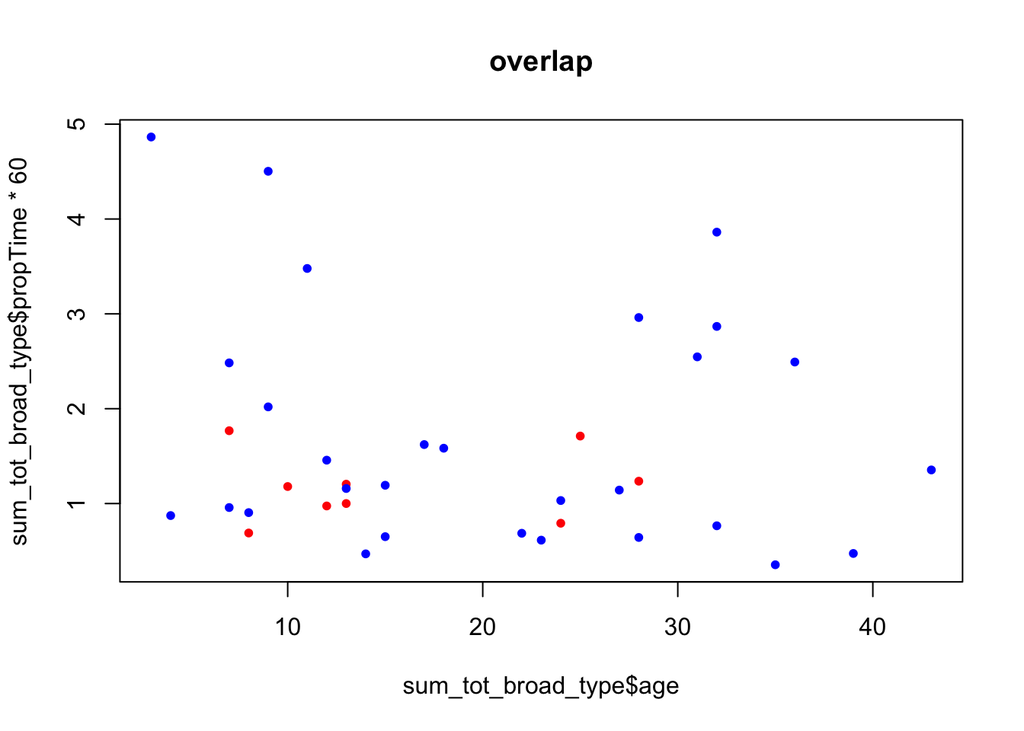

```r
for(thistype in levels(as.factor(sum_tot_broad_type$speakerID_broad))){
  plot(sum_tot_broad_type$propTime*60 ~ sum_tot_broad_type$age,col=ifelse(substr(as.character(sum_tot_broad_type$key),7,7)=="v","red","blue"),subset=c(sum_tot_broad_type$speakerID_broad==thistype),pch=20,main=thistype)
}
```

```r
read.table("../derivedFiles/line_per_chunk.txt",header=T)->sums

sums[grep("CHI",sums$source,invert=T),]->sums #get rid of all CHI and overlaps with CHI

sums$dur.prop=sums$dur/60 # since these are sums per chunk with overlap accounted for, the max possible is 60

# now we have a table with one line summing over individual speakers and overlap segments
# We want a table with one line per kid per visit with total proportions

# so next step is to sum WITHIN CHUNK/FILE collapsing within broad classes
#this table has proportions of time per FILE/CHUNK per speaker class
aggregate(sums$dur.prop,by=list(sums$key,sums$File,sums$speakerID_broad,sums$age),sum,na.rm=T)->sum_file_tot_type #since here we are collapsing across subtypes, we should do SUM, not MEAN
colnames(sum_file_tot_type)<-c("key","File","speakerID_broad","age","propTime")

#and now we can just do averages across all chunks within a given child visit
aggregate(sum_file_tot_type$propTime,by=list(sum_file_tot_type$key,sum_file_tot_type$speakerID_broad,sum_file_tot_type$age),mean,na.rm=T)->input_averages #since here we are deriving the overall averages, we should do MEAN
colnames(input_averages)<-c("key","speakerID_broad","age","propTime")

#and finally sums
aggregate(input_averages$propTime,by=list(input_averages$key,input_averages$age),sum,na.rm=T)->overall_sum
colnames(overall_sum)<-c("key","age","propTime")


aggregate(sum_visit$tot.CFRL[sum_visit$source %in% nonOLnonCHI],by=list(sum_visit$key[sum_visit$source %in% nonOLnonCHI],sum_visit$source[sum_visit$source %in% nonOLnonCHI],sum_visit$age[sum_visit$source %in% nonOLnonCHI]),sum)->tot_talking_nonOL
colnames(tot_talking_nonOL)<-c("key","source","age","tot")

aggregate(sum_visit$tot.CFRL[sum_visit$source %in% nonCHI],by=list(sum_visit$key[sum_visit$source %in% nonCHI],sum_visit$source[sum_visit$source %in% nonCHI],sum_visit$age[sum_visit$source %in% nonCHI]),sum)->tot_talking
colnames(tot_talking)<-c("key","source","age","tot")

summary(tot_talking)
tot_talking$broad=substr(tot_talking$source,1,1)
tot_talking$broad[tot_talking$source=="FA1"]<-"MOT"
tot_talking$broad[grep(" ",tot_talking$source)]<-"overlap"

plot(tot_talking$tot ~ tot_talking$age,xlab="age (m)",ylab="tot")
#########
aggregate(sums$propTot,by=list(sums$key,sums$source,sums$age),sum,na.rm=T)->sum_visit
colnames(sum_visit)<-c("key","source","age","propTot")

all_sources=as.character(levels(sum_visit$source))
nonCHI=all_sources[-grep("CHI",all_sources)]

nonOL=all_sources[-grep(" ",all_sources)]
nonOL=nonOL[-grep("XOL",nonOL)]
nonOLnonCHI=nonOL[-grep("CHI",nonOL)]

aggregate(sum_visit$propTot[sum_visit$source %in% nonOLnonCHI],by=list(sum_visit$key[sum_visit$source %in% nonOLnonCHI],sum_visit$age[sum_visit$source %in% nonOLnonCHI]),sum)->tot_talking_nonOL
colnames(tot_talking_nonOL)<-c("key","age","tot")

aggregate(sum_visit$propTot[sum_visit$source %in% nonCHI],by=list(sum_visit$key[sum_visit$source %in% nonCHI],sum_visit$age[sum_visit$source %in% nonCHI]),sum)->tot_talking
colnames(tot_talking)<-c("key","age","tot")
```

[output not shown]

# TO DO:

- identify what I could possibly have meant by: “CHI. voc auqntm speech auqntm ratio”
- add recording onset time
- only then describe quant over hours

# Stability section

```r
read.table("../derivedFiles/propling_age.txt", header=T)->sumchi
selvars=c("ling","nonling","tot","prop","ling.CFRL","nonling.CFRL")

twodays=NULL
for(eachkid in names(table(sumchi$chag))[table(sumchi$chag)>1 & substring(names(table(sumchi$chag)),1,1)!="v"]){
  subset(sumchi,chag==eachkid)->thischidat
  odd_days=cbind(thischidat[1,c("child","age","chag")],
             t( colMeans(thischidat[seq(1,dim(thischidat)[1],by=2),selvars],na.rm=T)),
              sum(thischidat[seq(1,dim(thischidat)[1],by=2),c("nchunks")],na.rm=T),1)
  names(odd_days)[10:11]<-c("nchunks","day")

   even_days=cbind(thischidat[1,c("child","age","chag")],
             t( colMeans(thischidat[seq(2,dim(thischidat)[1],by=2),selvars],na.rm=T)),
              sum(thischidat[seq(2,dim(thischidat)[1],by=2),c("nchunks")],na.rm=T),2)
  names(even_days)[10:11]<-c("nchunks","day")
    twodays=rbind(twodays, odd_days,even_days )
}

#thisdv="ling.CFRL"
for(thisdv in "ling.CFRL"){
  temp=table(twodays$chag[!is.na(twodays[,thisdv])])
  goodkids=names(temp)[temp==2]

   pdf(paste0(thisdv,".pdf"),height=15,width=15,pointsize = 36)
  par(mar=c(2.5, 2.5, 1, 1))

  plot(twodays[twodays$day==2 & twodays$chag %in% goodkids,thisdv]~twodays[twodays$day==1 & twodays$chag %in% goodkids,thisdv],xaxt="n",yaxt="n", main="",xlim=range(twodays[,thisdv],na.rm=T),ylim=range(twodays[,thisdv],na.rm=T), type="n")
  axis(1,tick=F,line=-1)
  axis(2,tick=F,line=-1)
  mtext("Odd days",1,line=1)
  mtext("Even days",2,line=1)

  text(twodays[twodays$day==1 & twodays$chag %in% goodkids,thisdv],twodays[twodays$day==2 & twodays$chag %in% goodkids,thisdv], twodays[twodays$day==2 & twodays$chag %in% goodkids,"chag"],
       col=rainbow(length(twodays$day==2 & twodays$chag %in% goodkids)))
  mylm=lm(twodays[twodays$day==2,thisdv]~twodays[twodays$day==1,thisdv] + (1/twodays$child[twodays$day==2]),subset=c(twodays$chag %in% goodkids))
abline(mylm)
dev.off()

print(summary(mylm))
print(cor.test(twodays[twodays$day==2 & twodays$chag %in% goodkids ,thisdv],twodays[twodays$day==1 & twodays$chag %in% goodkids,thisdv],method="s"))
difvec=abs(twodays[twodays$day==2 & twodays$chag %in% goodkids,thisdv] - twodays[twodays$day==1 & twodays$chag %in% goodkids,thisdv])
print(summary(difvec*100))
print(cbind(as.character(twodays[twodays$day==2 & twodays$chag %in% goodkids,"chag"]),difvec))
}
```

```
##
## Call:
## lm(formula = twodays[twodays$day == 2, thisdv] ~ twodays[twodays$day ==
##     1, thisdv] + (1/twodays$child[twodays$day == 2]), subset = c(twodays$chag %in%
##     goodkids))
##
## Residuals:
##       Min        1Q    Median        3Q       Max
## -0.055037 -0.018141 -0.002617  0.014572  0.050409
##
## Coefficients:
##                                   Estimate Std. Error t value Pr(>|t|)
## (Intercept)                        0.02047    0.01048   1.954 0.061136 .
## twodays[twodays$day == 1, thisdv]  0.52842    0.13135   4.023 0.000416 ***
## ---
## Signif. codes:  0 '***' 0.001 '**' 0.01 '*' 0.05 '.' 0.1 ' ' 1
##
## Residual standard error: 0.02795 on 27 degrees of freedom
##   (29 observations deleted due to missingness)
## Multiple R-squared:  0.3748, Adjusted R-squared:  0.3516
## F-statistic: 16.18 on 1 and 27 DF,  p-value: 0.0004165
##
##
##  Spearman's rank correlation rho
##
## data:  twodays[twodays$day == 2 & twodays$chag %in% goodkids, thisdv] and twodays[twodays$day == 1 & twodays$chag %in% goodkids, thisdv]
## S = 2042, p-value = 0.006685
## alternative hypothesis: true rho is not equal to 0
## sample estimates:
##       rho
## 0.4970443
##
##     Min.  1st Qu.   Median     Mean  3rd Qu.     Max.
##  0.08183  0.51750  2.07467  2.54376  3.77674 10.89574
##                difvec
##  [1,] "aiku11" "0.0183128787878789"
##  [2,] "aiku15" "0.0023050724637682"
##  [3,] "aiku7"  "0.0506553030303029"
##  [4,] "aoaa24" "0.0470316723901099"
##  [5,] "aoaa28" "0.0524831944444445"
```

[output cut: 9 more lines]

```
## [15,] "noxk4"  "0.0081227083333333"
## [16,] "noxk8"  "0.00754791666666666"
## [17,] "noxt15" "0.0017179487179485"
## [18,] "noxt7"  "0.00517500000000019"
## [19,] "oegd35" "0.0314648809523805"
## [20,] "oegd39" "0.0605263725490195"
## [21,] "oegd43" "0.0167482142857142"
## [22,] "oekd13" "0.0209644841269841"
## [23,] "oekd17" "0.00319547404880075"
## [24,] "oekd9"  "0.00407067460317456"
## [25,] "outg9"  "0.0019222222222221"
## [26,] "uebn23" "0.108957446581197"
## [27,] "uebn27" "0.0466385416666664"
## [28,] "uebn31" "0.0268181196581191"
## [29,] "uoga3"  "0.0341648412698414"
```